# Datenvisualisierung mit R

Regressionen

Armin Schäfer

schaefer@politik.uni-mainz.de

10.07.2025

## Regressionsmodelle

1. Wie lassen sich die Ergebnisse in Tabellen zusammenfassen?
2. Wie lassen sich die Koeffizienten grafisch darstellen?
3. Wie lassen sich die vorhergesagten Werte ermitteln und darstellen?
4. Wie lassen sich Interaktionseffekte interpretieren und visualisieren?

## Zur Vorbereitung I

Fügen Sie bitte dem Ordner “Datavis” die Unterordner “tables” sowie “figs” hinzu.

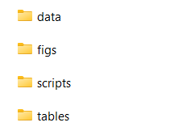

## Zur Vorbereitung II

Um Regressionstabellen und -modelle darstellen zu können, benötigen wir einige Bibliotheken, die wir bislang noch nicht verwendet haben. Dazu gehören `broom`, `modelsummary`, `marginaleffects`, `datawizard` sowie `modelbased`, die zunächst installiert werden müssen.

Wir verwenden heute den Datensatz `wkr_daten.csv`.

## Neue Variable erstellen

```r
wkr_daten <- wkr_daten %>%
  mutate(bildung = case_when(
    abitur>=20 & abitur < 31.3   ~ "niedrig",
    abitur>=31.3 & abitur < 42.6 ~ "mittel",
    abitur>=42.6 & abitur < 54   ~ "hoch"),
    bildung = fct_relevel(bildung, "niedrig", "mittel", "hoch")) %>%
    rename(region = ost)
```

## Ein erster Blick auf die Daten

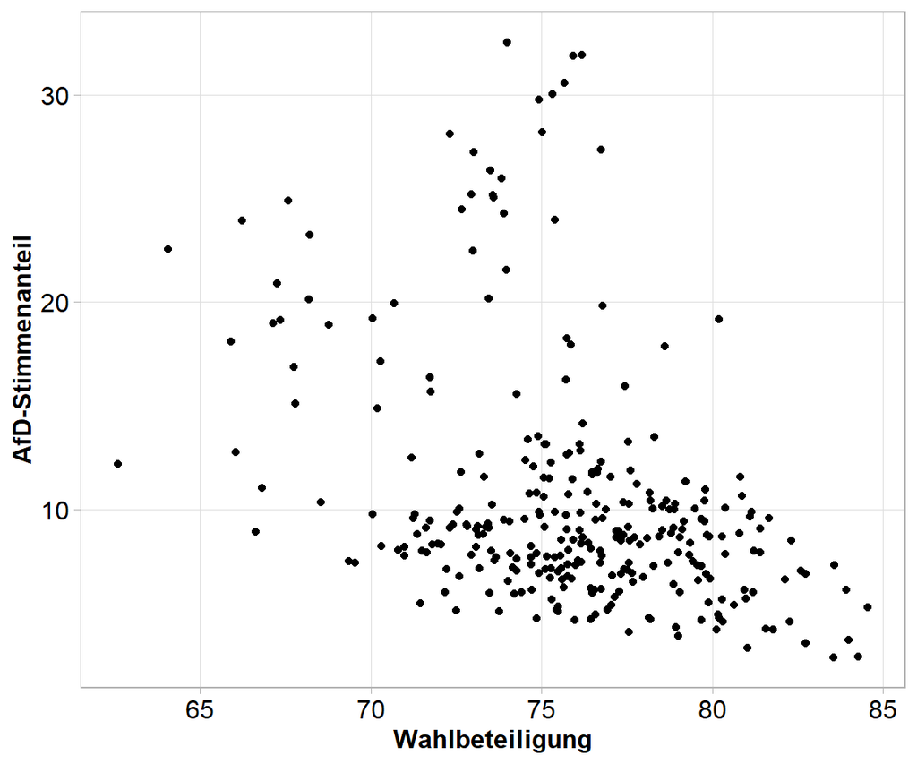

```r
ggplot(data = wkr_daten,
       aes(x = wbt,
           y = afd_perc))+
  geom_point()+
  labs(x = "Wahlbeteiligung",
       y = "AfD-Stimmenanteil",
       color = NULL)+
  theme_light()+
  my_theme()
```

## Ost- und Westdeutschland

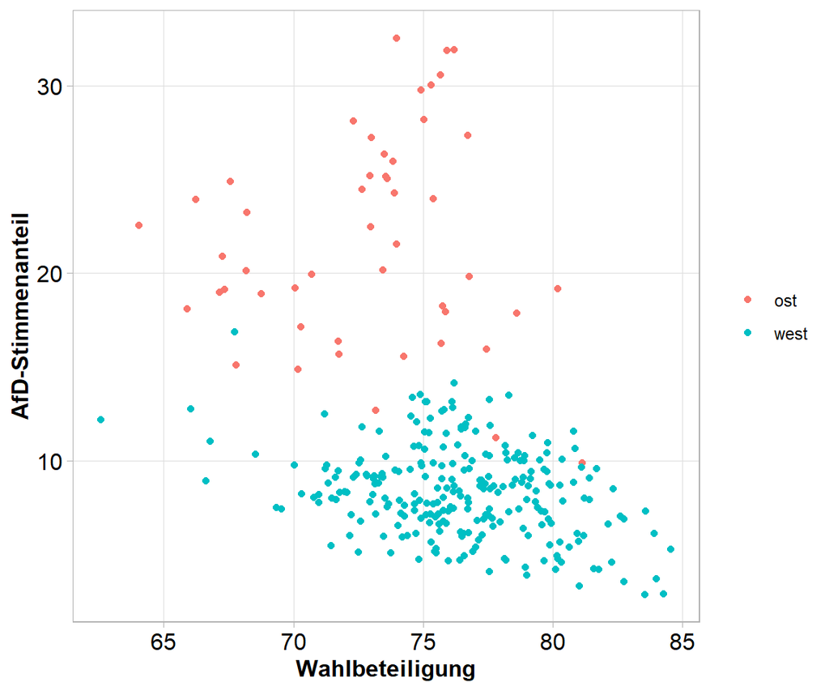

```r
ggplot(data = wkr_daten,
       aes(x = wbt,
           y = afd_perc,
           color = region))+
  geom_point()+
  labs(x = "Wahlbeteiligung",
       y = "AfD-Stimmenanteil",
       color = NULL)+
  theme_light()+
  my_theme()
```

## Ost- und Westdeutschland

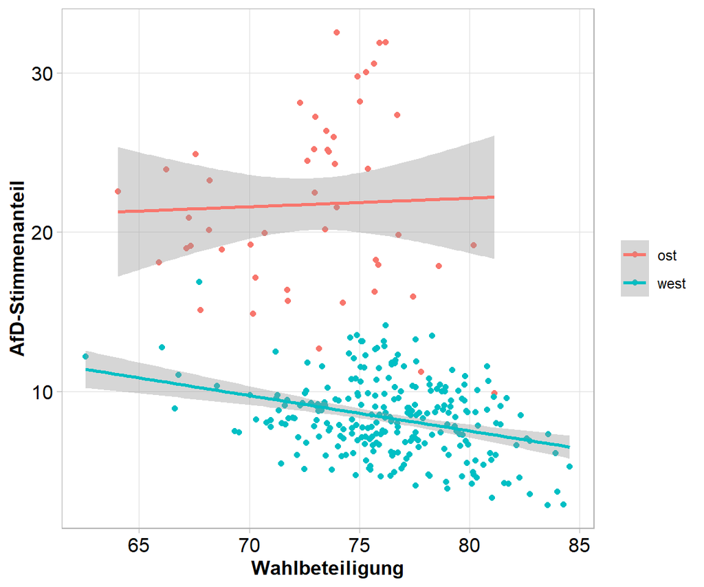

```r
ggplot(data = wkr_daten,
       aes(x = wbt,
           y = afd_perc,
           color = region))+
  geom_point()+
  geom_smooth(method = "lm")+
  labs(x = "Wahlbeteiligung",
       y = "AfD-Stimmenanteil",
       color = NULL)+
  theme_light()+
  my_theme()
```

## Ein lineares Regressionsmodell

```r
lm(afd_perc ~ wbt + region + bildung, data = wkr_daten)
```

**Hinweis**

Die Befehle folgen immer dem gleichen Aufbau. Zunächst wird festgelegt, welches Modell verwendet wird. `lm` steht für ein lineares Regressionsmodell. Andere varianten sind `glm` für generalisierte lineare Modelle oder `lmer` für ein lineares Mehrebenenmodell. Dann folgt die Formel, die angibt, welche Variable als abhängige Variable verwendet wird, nach der `~` gefolgt von den unabhängigen Variablen, die mit Pluszeichen verknüpft werden. Die Daten werden mit `data =` angegeben.

## Ein lineares Regressionsmodell

Wir schätzen zunächst das Modell und zeigen die Ergebnisse mit `summary()` an.

```r
m1 <- lm(afd_perc ~ wbt + region + bildung, data = wkr_daten)
summary(m1)
```

```
Call:
lm(formula = afd_perc ~ wbt + region + bildung, data = wkr_daten)

Residuals:
    Min      1Q  Median      3Q     Max
-8.7829 -1.3865 -0.1124  1.1871 11.5334

Coefficients:
               Estimate Std. Error t value Pr(>|t|)
(Intercept)    35.40188    3.27152  10.821  < 2e-16 ***
wbt            -0.16365    0.04445  -3.681 0.000276 ***
regionwest    -12.60611    0.45048 -27.984  < 2e-16 ***
bildungmittel  -2.64900    0.34605  -7.655 2.80e-13 ***
bildunghoch    -4.00197    0.46381  -8.628 3.97e-16 ***
---
Signif. codes:  0 '***' 0.001 '**' 0.01 '*' 0.05 '.' 0.1 ' ' 1

Residual standard error: 2.698 on 294 degrees of freedom
Multiple R-squared:  0.7923,    Adjusted R-squared:  0.7895
F-statistic: 280.4 on 4 and 294 DF,  p-value: < 2.2e-16
```

## Informationen abrufen

Die Funktion `summary()` hilft uns zwar, die Informationen eines Regressionsmodells kompakt darzustellen, erlaubt aber nicht ohne weiteres, weitere Analysen durchzuführen – beispielsweise die Koeffizienten in einer Grafik darzustellen. Wir können aber auf einzelne Elemente zugreifen. Geben Sie dazu `str(m1)` in die Konsole ein. Dort sehen Sie, welche Informationen `summary(m1)` enthält.

Mit `m1$coefficients` können wir uns beispielsweise die Koeffizienten anzeigen lassen. Und mit `m1$coefficients["wbt"]` rufen wir nur den Koeffizienten für die Wahlbeteiligung ab.

## Informationen mit `broom` erhalten

Um die Ergebnisse als bearbeitbaren Datensatz zu erhalten, nutzen wir das Paket broom. Der dort enthaltene Befehl, um die Modell-Informationen in eine Datentabelle zu überführen, ist `tidy()`.

```r
tidy(m1, conf.int = TRUE) %>%
  mutate(across(where(is.numeric), ~round(., 2))) %>% tt() %>% style_tt(fontsize = .6)
```

| term | estimate | std.error | statistic | p.value | conf.low | conf.high |
| --- | --- | --- | --- | --- | --- | --- |
| (Intercept) | 35.40 | 3.27 | 10.82 | 0 | 28.96 | 41.84 |
| wbt | -0.16 | 0.04 | -3.68 | 0 | -0.25 | -0.08 |
| regionwest | -12.61 | 0.45 | -27.98 | 0 | -13.49 | -11.72 |
| bildungmittel | -2.65 | 0.35 | -7.65 | 0 | -3.33 | -1.97 |
| bildunghoch | -4.00 | 0.46 | -8.63 | 0 | -4.91 | -3.09 |

## Was sagt das Modell aus?

| term | estimate | std.error | statistic | p.value | conf.low | conf.high |
| --- | --- | --- | --- | --- | --- | --- |
| (Intercept) | 35.40 | 3.27 | 10.82 | 0 | 28.96 | 41.84 |
| wbt | -0.16 | 0.04 | -3.68 | 0 | -0.25 | -0.08 |
| regionwest | -12.61 | 0.45 | -27.98 | 0 | -13.49 | -11.72 |
| bildungmittel | -2.65 | 0.35 | -7.65 | 0 | -3.33 | -1.97 |
| bildunghoch | -4.00 | 0.46 | -8.63 | 0 | -4.91 | -3.09 |

Wenn alle unabhängigen Variablen den Wert 0 annehmen, wird der AfD-Anteil auf 35.4 geschätzt. Warum ist das nicht besonders aussagekräftig?

```r
# Anteil in O-D bei mittlerer WBT und niedrigem Abi-Anteil
m1$coefficients["(Intercept)"] + m1$coefficients["wbt"] * mean(wkr_daten$wbt, na.rm=TRUE)
```

```
(Intercept)
    22.9971
```

## Variablen vorab zentrieren

```r
wkr_daten <- wkr_daten %>%
  mutate(wbt_c = wbt - mean(wbt, na.rm = TRUE)) # Mittelwert abziehen

m1 <- lm(afd_perc ~ wbt_c + region + bildung, data = wkr_daten)

round(m1$coefficients["(Intercept)"],4)
```

```
(Intercept)
    22.9971
```

## Ergebnisse des Regressionsmodells speichern

```r
coef_m1 <- tidy(m1, conf.int = TRUE)%>%
  mutate(across(where(is.numeric), ~round(., 2)))

coef_m1 %>% tt() %>% style_tt(fontsize = .6)
```

| term | estimate | std.error | statistic | p.value | conf.low | conf.high |
| --- | --- | --- | --- | --- | --- | --- |
| (Intercept) | 23.00 | 0.45 | 51.16 | 0 | 22.11 | 23.88 |
| wbt_c | -0.16 | 0.04 | -3.68 | 0 | -0.25 | -0.08 |
| regionwest | -12.61 | 0.45 | -27.98 | 0 | -13.49 | -11.72 |
| bildungmittel | -2.65 | 0.35 | -7.65 | 0 | -3.33 | -1.97 |
| bildunghoch | -4.00 | 0.46 | -8.63 | 0 | -4.91 | -3.09 |

## Variablennamen ändern

Der Output von `tidy()` ist mit den `tidyverse()`-Bibliotheken kompatibel, wir können den Datensatz also bearbeiten:

```r
coef_m1 <- coef_m1 %>%
  mutate(term = recode(term, wbt_c = "Wahlbeteiligung"))

head(coef_m1) %>% tt() %>% style_tt(fontsize = .6)
```

| term | estimate | std.error | statistic | p.value | conf.low | conf.high |
| --- | --- | --- | --- | --- | --- | --- |
| (Intercept) | 23.00 | 0.45 | 51.16 | 0 | 22.11 | 23.88 |
| Wahlbeteiligung | -0.16 | 0.04 | -3.68 | 0 | -0.25 | -0.08 |
| regionwest | -12.61 | 0.45 | -27.98 | 0 | -13.49 | -11.72 |
| bildungmittel | -2.65 | 0.35 | -7.65 | 0 | -3.33 | -1.97 |
| bildunghoch | -4.00 | 0.46 | -8.63 | 0 | -4.91 | -3.09 |

## Koeffizienten darstellen

Erstellen Sie nun mit dem Datensatz `coef_m1` eine Grafik, das die Namen der Koeffizienten auf der einen Achse abträgt und den Wert des Koeffizienten als Punkte im Diagramm darstellt.

## Koeffizienten darstellen

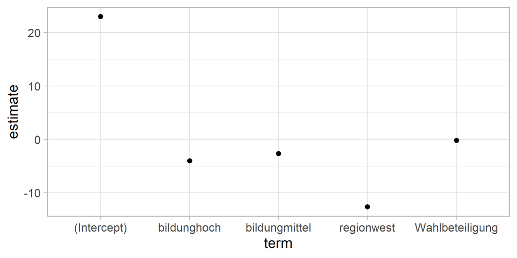

```r
ggplot(data = coef_m1,
       aes(x = term,
           y = estimate))+
  geom_point(size = 3)+
  theme_light(base_size = 20)
```

Der Zusatz “base_size = 20” ist nur notwendig, um die Grafik auf den Folien lesbar zu halten.

## Koeffizienten ohne Achsenabschnitt (= Intercept) darstellen

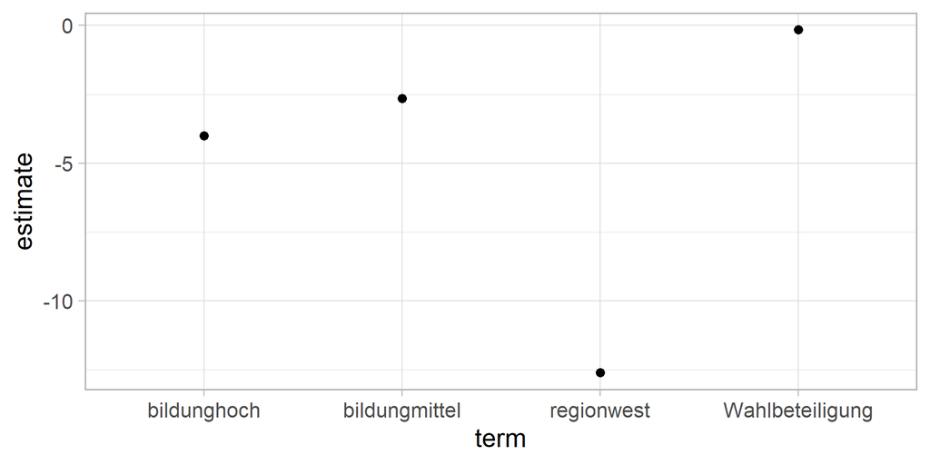

```r
coef_m1 %>%
  filter(term !="(Intercept)") %>%
ggplot(aes(x = term,
           y = estimate))+
  geom_point(size = 3)+
  theme_light(base_size = 20)
```

Wie können wir die Konfidenzintervalle zustätzlich darstellen?

## Koeffizienten grafisch darstellen

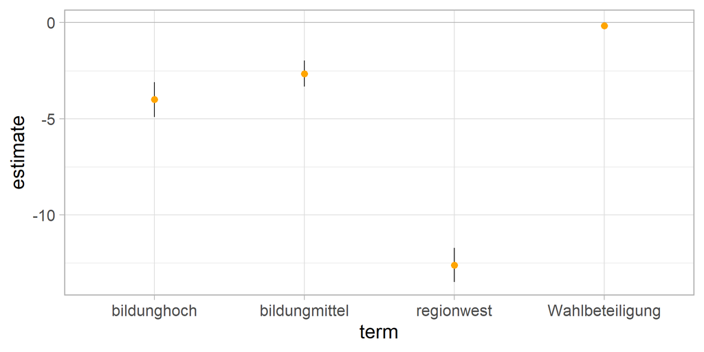

```r
coef_m1 %>%
  filter(term !="(Intercept)") %>%
ggplot(aes(x = term, y = estimate))+
  geom_hline(yintercept = 0,
             color = "grey70")+
  geom_linerange(aes(ymin = conf.low,
                     ymax = conf.high))+
  geom_point(size = 3, color = "orange")+
  theme_light(base_size = 20)
```

## Koeffizienten grafisch darstellen

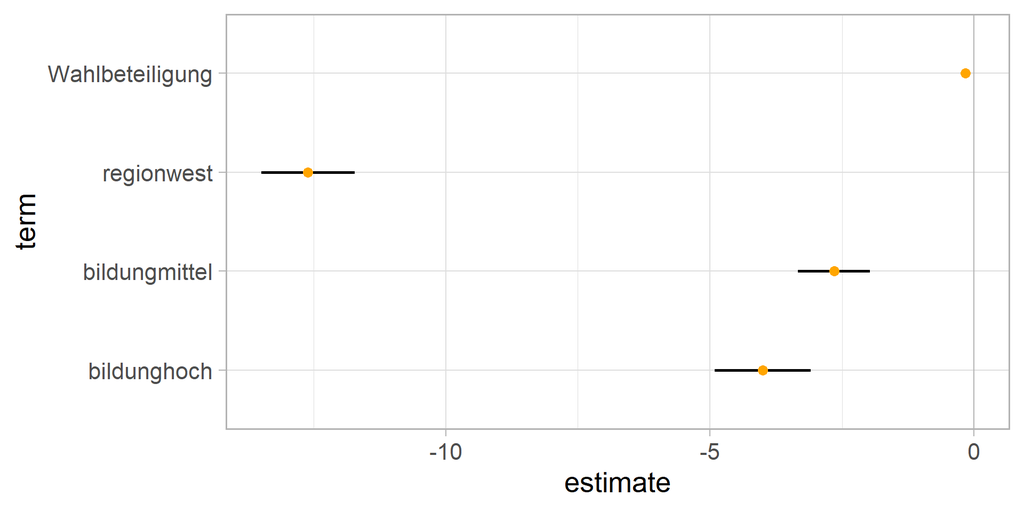

```r
coef_m1 %>%
  filter(term !="(Intercept)") %>%
ggplot(aes(x = term, y = estimate))+
  geom_hline(yintercept = 0,
             color = "grey70")+
  geom_linerange(aes(ymin = conf.low,
                     ymax = conf.high),
                 linewidth = .9)+
  geom_point(size = 3,
             color = "orange")+
  theme_light(base_size = 20)+
  coord_flip()
```

## `modelsummary` nutzt `broom`!

Statt die Daten selbst abzurufen, könnnen wir [modelsummary](https://modelsummary.com/vignettes/get_started.html) verwenden, das im Hintergrund ebenfalls broom nutzt. Im Folgenden verwenden wir zwei Regressionsmodelle.

```r
models <- list(
  "Modell 1" = lm(afd_perc ~ wbt_c + bildung, data = wkr_daten), # Gleichheitszeichen!
  "Modell 2" = lm(afd_perc ~ wbt_c + bildung + region, data = wkr_daten)
)

modelsummary(models) %>% style_tt(fontsize = .6)
```

[output not shown]

## Die Tabelle weiter anpassen

```r
coefname <- c(
        'wbt_c'         = "Wahlbeteiligung (%)",
        'bildungmittel' = 'mittlere Bildung',
        'bildunghoch'   = 'hohe Bildung',
        'regionwest'    = 'Westdeutschland',
        '(Intercept)'   = 'Konstante')

modelsummary(models,
             estimate = "{estimate}{stars}", # Koeffiziente und Signifikanzsterne
             gof_omit = 'AIC|BIC|Log.Lik|F|RMSE', # Modellgüte-Parameter ausschließen
             coef_map = coefname) %>% # oben definierte Namen verwenden
   style_tt(fontsize = .6)
```

Auf der Webseite für [tinytable](https://vincentarelbundock.github.io/tinytable/) werden zahlreiche weitere Gestaltungsmöglichkeiten für Tabellen vorgestellt.

## Angepasste Tabelle

|  | Modell 1 | Modell 2 |
| --- | --- | --- |
| Wahlbeteiligung (%) | -0.596*** | -0.164*** |
|  | (0.080) | (0.044) |
| mittlere Bildung | -3.099*** | -2.649*** |
|  | (0.661) | (0.346) |
| hohe Bildung | -4.495*** | -4.002*** |
|  | (0.886) | (0.464) |
| Westdeutschland |  | -12.606*** |
|  |  | (0.450) |
| Konstante | 12.753*** | 22.997*** |
|  | (0.498) | (0.450) |
| Num.Obs. | 299 | 299 |
| R2 | 0.239 | 0.792 |
| R2 Adj. | 0.231 | 0.790 |

## Tabellen exportieren

```r
modelsummary(models,
             estimate = "{estimate}{stars}",
             gof_omit = 'AIC|BIC|Log.Lik|F|RMSE',
             coef_map = coefname,
             output = here("tables", "table.docx")) # als Word-Dokument speichern
```

## Koeffizientenplot

Praktischerweise erlaubt modelsummary es auch, Koeffizientenplots darzustellen. Die Syntax ist ganz ähnlich und wir können `ggplot()`-Elemente ergänzen:

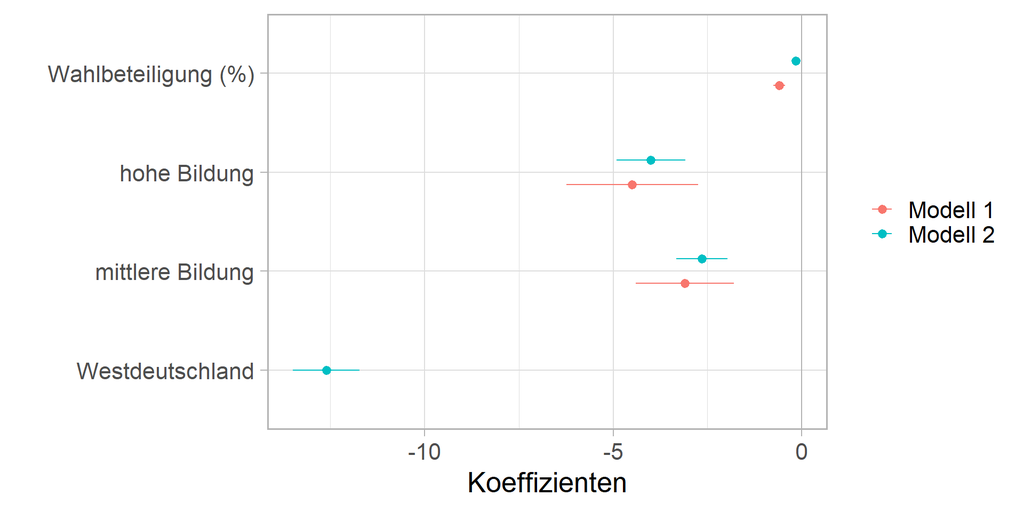

```r
coefname <- c(
        'regionwest'    = 'Westdeutschland',
        'bildungmittel' = 'mittlere Bildung',
        'bildunghoch'   = 'hohe Bildung',
        'wbt_c'         = "Wahlbeteiligung (%)")

modelplot(models, coef_map = coefname)+
  geom_vline(xintercept = 0,
             color = "grey70")+
  labs(x = "Koeffizienten",
       color = NULL)+
  theme_light(base_size = 20)
```

# Vorhergesagte Werte ermitteln

## `Predicted values` und `marginal effects`

Leider werde Begriffe in der Statistik häufig uneinheitlich verwendet. Insbesondere der Begriff “marginale Effekte” hat zahlreiche unterschiedliche Verwendungen.<sup>1</sup> Wir verstehen unter marginalen Effekten die Änderung des Erwartungswerts der abhängigen Variable bei einer kleinen (bzw. diskreten) Änderung einer unabhängigen Variable, unter Konstanthaltung der übrigen Variablen.

In linearen Modellen entspricht der Regressionskoeffizient dem marginalen Effekt. In nichtlinearen Modellen (z.B. bei logistischen Regressionsmodellen) ist das jedoch nicht der Fall, da der *Effekt der unabhängigen Variable* in Abhängigkeit vom Niveau anderer Variablen variiert. Bei logistischen Modellen müssen marginale Effekte deshalb separat berechnet werden.

[^1]: Mehr hierzu im Blog von [Andrew Heiss](https://www.andrewheiss.com/blog/2022/05/20/marginalia/).

## Wie hoch ist der AfD-Anteil in Ost- und Westdeutschland im Durchschnitt

Zunächst schauen wir uns die Mittelwerte an, die sich aus den Rohdaten ermitteln lassen:

```r
wkr_daten %>%
  group_by(region) %>%
  summarise(mean = mean(afd_perc, na.rm = TRUE)) %>%
  mutate(mean = round(mean, 2)) %>%
  tt() %>% style_tt(fontsize = .6)
```

| region | mean |
| --- | --- |
| ost | 21.75 |
| west | 8.33 |

## Vorhergesagte (Mittel-)Werte

```r
model <- lm(afd_perc ~ wbt_c + bildung + region, data = wkr_daten)

means <- estimate_means(model, by = "region")
means %>% tt() %>% style_tt(fontsize = .6) %>% format_tt(digits = 2)
```

| region | Mean | SE | CI_low | CI_high | t | df |
| --- | --- | --- | --- | --- | --- | --- |
| ost | 20.8 | 0.41 | 20 | 21.6 | 50 | 294 |
| west | 8.2 | 0.19 | 7.8 | 8.5 | 44 | 294 |

“Other predictors of the model that are not included here will be collapsed and ‘averaged’ over (the effect will be estimated across them).” Die Werte berücksichtigen den durchschnittlichen Effekt der anderen Variablen.

## Vorhergesagte (Mittel-)Werte

```r
model <- lm(afd_perc ~ wbt_c + bildung + region, data = wkr_daten)

means_bild <- estimate_means(model, by = "bildung")
means_bild %>% tt() %>% style_tt(fontsize = .6) %>% format_tt(digits = 3)
```

| bildung | Mean | SE | CI_low | CI_high | t | df |
| --- | --- | --- | --- | --- | --- | --- |
| niedrig | 16.7 | 0.296 | 16.1 | 17.3 | 56.3 | 294 |
| mittel | 14 | 0.276 | 13.5 | 14.6 | 50.9 | 294 |
| hoch | 12.7 | 0.415 | 11.9 | 13.5 | 30.6 | 294 |

[output not shown]

## Geschätzter Mittelwert und Datenverteilung

```r
ggplot(wkr_daten, aes(x = region, y = afd_perc)) +
  geom_violin(aes(fill = region), color = "white") +
  geom_jitter(width = 0.05, height = 0, alpha = 0.2, size = 2) +
  geom_pointrange(
    data = means,
    aes(y = Mean, ymin = CI_low, ymax = CI_high),
    size = 0.8,
    color = "white", linewidth = 0.9) +
  scale_y_continuous(limits = c(0, 35)) +
  scale_fill_manual(values = c("pink", "lightgreen")) +
  theme_minimal()+
  guides(fill = "none")
```

## Geschätzter Mittelwert und Datenverteilung

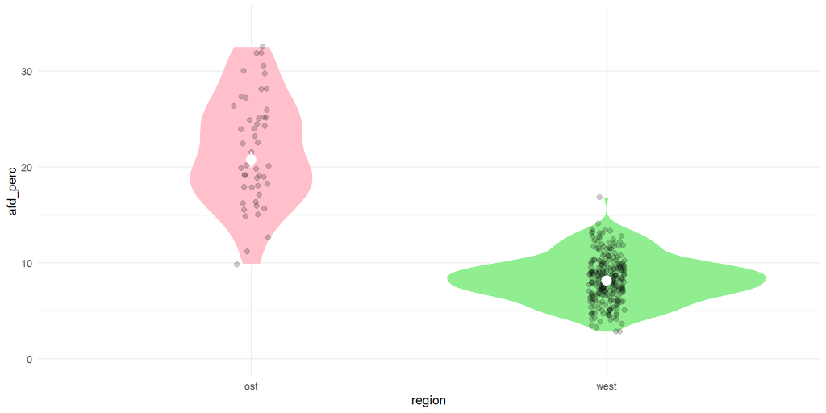

## Kontraste = marginaler Effekt

```r
contrasts <- estimate_contrasts(model, contrast = "bildung") # Differenz der Gruppen
contrasts %>% mutate(across(where(is.numeric), ~ round(., 2))) %>% tt() %>% style_tt(fontsize = .6)
```

| Level1 | Level2 | Difference | SE | CI_low | CI_high | t | df | p |
| --- | --- | --- | --- | --- | --- | --- | --- | --- |
| mittel | niedrig | -2.65 | 0.35 | -3.33 | -1.97 | -7.65 | 294 | 0 |
| hoch | niedrig | -4.00 | 0.46 | -4.91 | -3.09 | -8.63 | 294 | 0 |
| hoch | mittel | -1.35 | 0.45 | -2.23 | -0.47 | -3.03 | 294 | 0 |

```r
contrasts <- estimate_contrasts(model, contrast = "region") # Differenz der Gruppen
contrasts %>% mutate(across(where(is.numeric), ~ round(., 2))) %>% tt() %>% style_tt(fontsize = .6)
```

| Level1 | Level2 | Difference | SE | CI_low | CI_high | t | df | p |
| --- | --- | --- | --- | --- | --- | --- | --- | --- |
| west | ost | -12.61 | 0.45 | -13.49 | -11.72 | -27.98 | 294 | 0 |

## Vorhergesagte Werte in einer Tabelle

Nun erweitern wir das Modell, indem wir einen Interaktionseffekt hinzufügen.

```r
model <- lm(afd_perc ~ wbt_c + region * bildung, # Interaktionseffekt
            data = wkr_daten)

estimate_means(model, by = c("region", "bildung")) %>%
  tt() %>% style_tt(fontsize = 0.6)
```

| region | bildung | Mean | SE | CI_low | CI_high | t | df |
| --- | --- | --- | --- | --- | --- | --- | --- |
| ost | niedrig | 24.675991 | 0.6201059 | 23.455547 | 25.896434 | 39.79319 | 292 |
| ost | mittel | 19.834367 | 0.5586073 | 18.734960 | 20.933774 | 35.50681 | 292 |
| ost | hoch | 16.197765 | 1.0728290 | 14.086307 | 18.309222 | 15.09818 | 292 |
| west | niedrig | 10.004480 | 0.2855038 | 9.442574 | 10.566386 | 35.04150 | 292 |
| west | mittel | 7.853531 | 0.2409468 | 7.379319 | 8.327744 | 32.59447 | 292 |
| west | hoch | 6.738457 | 0.3981757 | 5.954798 | 7.522115 | 16.92332 | 292 |

## Vorhergesagte Werte als Grafik

```r
estimate_means(model, by = c("region", "bildung")) %>%
  ggplot(aes(x = bildung, y = Mean, ymin = CI_low, ymax = CI_high, color = region))+
  geom_pointrange() +
  scale_y_continuous(limits = c(0, 30))+
  labs(x = "Bildung", y = "Vorhergesagter Wert")+
  theme_bw()
```

## Vorhergesagte Werte als Grafik

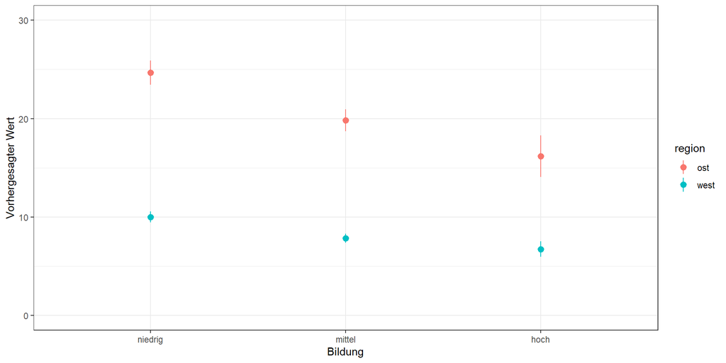

## Vorhergesagte Werte als Grafik

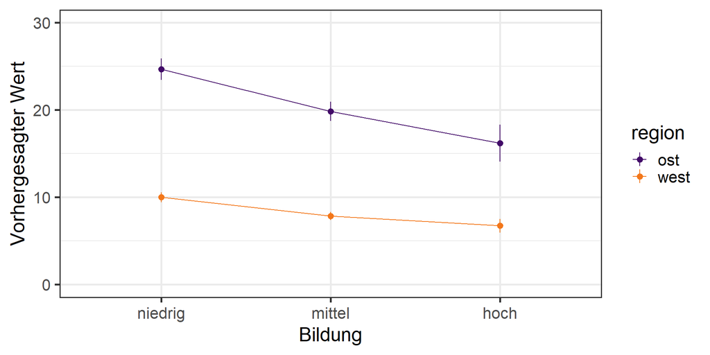

```r
estimate_means(model, by = c("region", "bildung")) %>%
  ggplot(aes(x = bildung, y = Mean,
               ymin = CI_low, ymax = CI_high,
               color = region))+
  geom_line(aes(group = region))+
  geom_pointrange() +
  scale_color_viridis_d(option = "inferno", begin = .2, end = .7)+
  scale_y_continuous(limits = c(0, 30))+
  labs(x = "Bildung", y = "Vorhergesagter Wert")+
  theme_bw(base_size = 20)
```

## Kontraste bei Interaktionseffekten

```r
model <- lm(afd_perc ~ wbt + region * bildung,
            data = wkr_daten)

difference <- estimate_contrasts(model,
  contrast = "bildung", by = "region") %>%
  mutate(across(where(is.numeric), ~ round(., 2)))

difference  %>% tt() %>%
  style_tt(fontsize = 0.6)
```

| Level1 | Level2 | region | Difference | SE | CI_low | CI_high | t | df | p |
| --- | --- | --- | --- | --- | --- | --- | --- | --- | --- |
| mittel | niedrig | ost | -4.84 | 0.81 | -6.43 | -3.25 | -5.99 | 292 | 0.00 |
| hoch | niedrig | ost | -8.48 | 1.24 | -10.92 | -6.04 | -6.83 | 292 | 0.00 |
| hoch | mittel | ost | -3.64 | 1.21 | -6.02 | -1.25 | -3.00 | 292 | 0.00 |
| mittel | niedrig | west | -2.15 | 0.37 | -2.88 | -1.42 | -5.77 | 292 | 0.00 |
| hoch | niedrig | west | -3.27 | 0.49 | -4.22 | -2.31 | -6.72 | 292 | 0.00 |
| hoch | mittel | west | -1.12 | 0.46 | -2.03 | -0.20 | -2.40 | 292 | 0.02 |

## Kontraste bei Interaktionseffekten

```r
difference <- difference %>%
  mutate(contrast = paste(difference$Level1, "-", difference$Level2)) # neue Bezeichnung

ggplot(data = difference,  aes(x = contrast, y = Difference,
           ymin = CI_low, ymax = CI_high, color = region))+
  geom_hline(yintercept = 0, color = "grey70", linewidth = 1.2)+
  geom_pointrange(position = position_dodge(width = 0.12), fatten = 6)+
  theme_light()
```

## Kontraste bei Interaktionseffekten

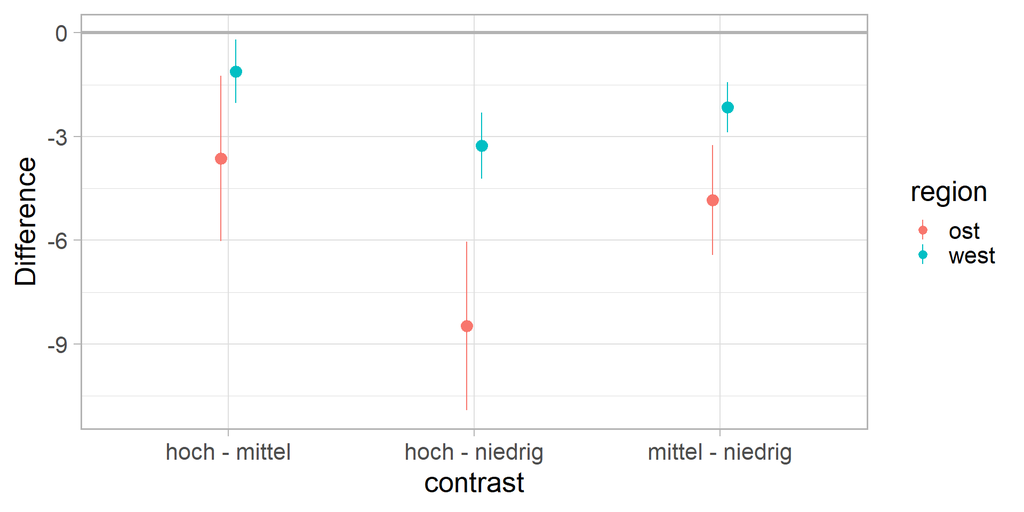

## Margainale Effekte bei Interaktionen

```r
model <- lm(afd_perc ~ wbt * region + abitur,
            data = wkr_daten)

difference <- estimate_contrasts(
  model,
  contrast = "region",
  by = "wbt",
  length = 5) %>% # 5 Werte für WBT
  mutate(across(where(is.numeric), ~ round(., 2)))

difference  %>% tt() %>%
  style_tt(fontsize = 0.6)
```

| Level1 | Level2 | wbt | Difference | SE | CI_low | CI_high | t | df | p |
| --- | --- | --- | --- | --- | --- | --- | --- | --- | --- |
| west | ost | 62.58 | -7.50 | 1.26 | -9.98 | -5.02 | -5.96 | 294 | 0 |
| west | ost | 68.07 | -10.09 | 0.73 | -11.53 | -8.66 | -13.83 | 294 | 0 |
| west | ost | 73.56 | -12.68 | 0.43 | -13.53 | -11.84 | -29.57 | 294 | 0 |
| west | ost | 79.06 | -15.27 | 0.73 | -16.72 | -13.83 | -20.82 | 294 | 0 |
| west | ost | 84.55 | -17.86 | 1.26 | -20.35 | -15.38 | -14.14 | 294 | 0 |

## Marginaler Effekt der Region (5 Werte für WBT)

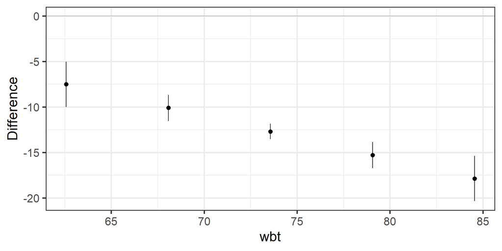

```r
ggplot(data = difference,
       aes(x = wbt,
           y = Difference,
           ymin = CI_low,
           ymax = CI_high))+
  geom_hline(yintercept = 0,
             color = "grey70")+
  geom_pointrange()+
  theme_bw(base_size = 20)
```

## Marginaler Effekt der Region (100 Werte für WBT)

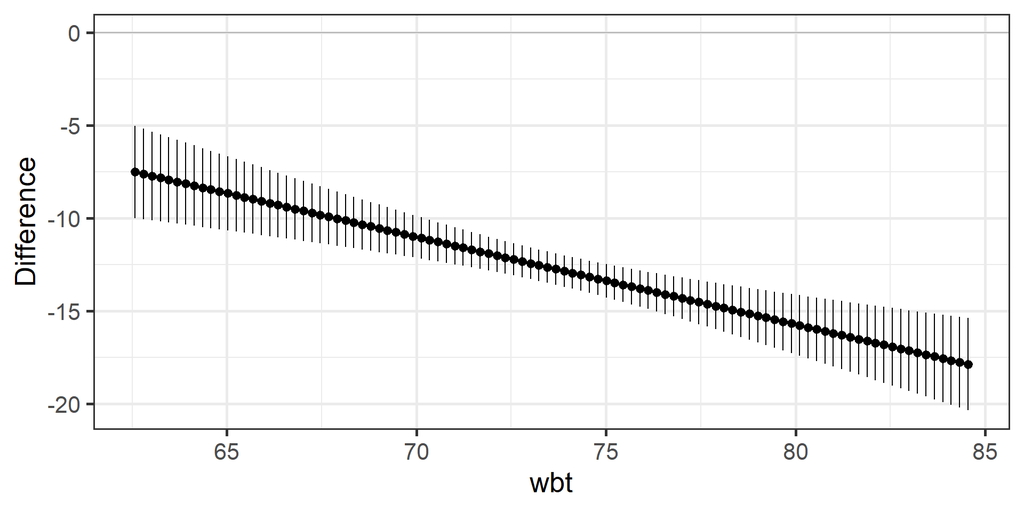

```r
estimate_contrasts(
  model,
  contrast = "region",
  by = "wbt",
  length = 100) %>% # 100
  ggplot(aes(x = wbt,
           y = Difference,
           ymin = CI_low,
           ymax = CI_high))+
  geom_hline(yintercept = 0,
             color = "grey70")+
  geom_pointrange()+
  theme_bw(base_size = 20)
```

## Vorhergesagte Werte nach Region

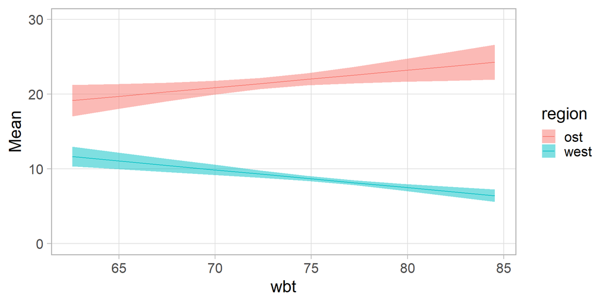

```r
estimate_means(model, by = c("region", "wbt")) %>%
  ggplot(aes(x = wbt, y = Mean,
             ymin = CI_low, ymax = CI_high,
             fill = region))+
  geom_ribbon(alpha = 0.5)+
  geom_line(aes(color = region))+
  scale_y_continuous(limits = c(0,30))+
  theme_light(base_size = 20)+
  theme(panel.grid.minor = element_blank())
```

## Marginaler Effekt der Region

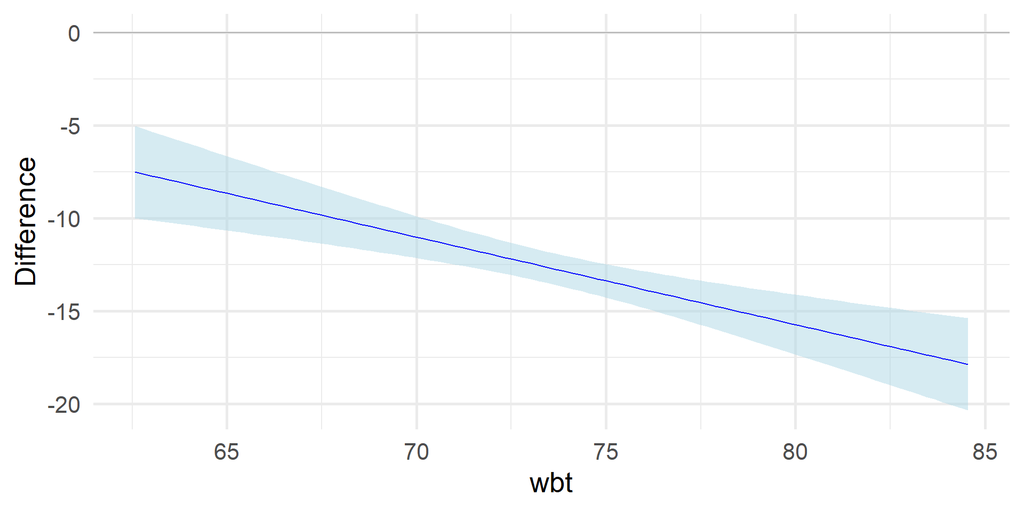

```r
estimate_contrasts(
  model,
  contrast = "region",
  by = "wbt",
  length = 100) %>%
  mutate(across(where(is.numeric), ~ round(., 2))) %>%
  ggplot(aes(x = wbt, y = Difference,
             ymin = CI_low, ymax = CI_high))+
  geom_hline(yintercept = 0,
             color = "grey70")+
  geom_ribbon(fill = "lightblue",
              alpha = 0.5)+
  geom_line(color = "blue")+
  theme_minimal(base_size = 20)
```

## Grafiken exportieren

```r
estimate_contrasts(
  model,
  contrast = "region",
  by = "wbt",
  length = 100) %>%
  ggplot(aes(x = wbt, y = Difference, ymin = CI_low, ymax = CI_high))+
  geom_hline(yintercept = 0, color = "grey70")+
  geom_ribbon(fill = "lightblue", alpha = 0.5)+ # für Konfidenzintervalle
  geom_line(color = "blue")+
  theme_minimal(base_size = 20)

ggsave(here("figs", "tbl-meffwbt.png"),
       units = c("in"),
       width = 6, height=4,
       dpi=300, bg = "white")
```